# Distribuzione_a_priori_soggettiva

NikolayNikolaev

2023-05-29

Nel seguito si illustra il metodo di specificazione soggettiva della prior. Si disegnano le probabilità tramite istogramma e si calcola la distribuzione a posteriori per la probabilità di sviluppare una certa malattia. Si supponga che vengono richieste le opinioni di tre dottori sulla quota di persone che possono sviluppare l’osteoporosi. Ogni dottore assegna un valore plausibile ai quantili seguenti

```r
p <- seq(0.05, 0.95, by = 0.1); p
```

```
##  [1] 0.05 0.15 0.25 0.35 0.45 0.55 0.65 0.75 0.85 0.95
```

Dalle somme dei valori assegnati dai dottori risulano i seguenti valori per la distribuzione a priori

```r
prior <- c(1, 5.2, 8, 7.2, 4.6, 2.1, 0.7, 0.1, 0, 0); prior
```

```
##  [1] 1.0 5.2 8.0 7.2 4.6 2.1 0.7 0.1 0.0 0.0
```

Si normalizzano i valori precedenti

```r
prior <- prior/sum(prior); prior
```

```
##  [1] 0.034602076 0.179930796 0.276816609 0.249134948 0.159169550 0.072664360
##  [7] 0.024221453 0.003460208 0.000000000 0.000000000
```

e l’istogramma rappresenta la distribuzione a priori per il parametro

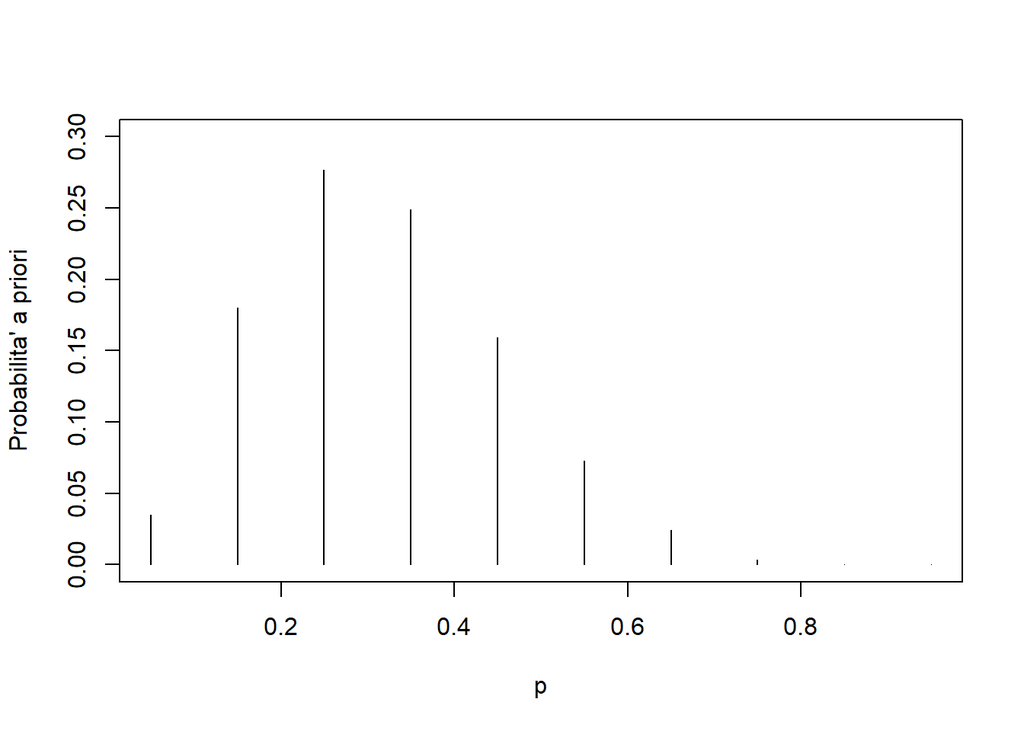

```r
plot(p, prior,
     ylim = c(0,0.30),
     type = "h",
     ylab="Probabilita' a priori",
     main = " ")
```

## Distribuzione a posteriori

Se ad esempio è disponibile un campione di 12 pazienti e si osserva che 6 hanno sviluppato l’osteoporsi, la funzione pdisc della libreria learnBayes permette di ricavare le le probabilita’ a posteriori. Questa richiede di speficiare per le osservazioni campionarie i successi (6) e gli insuccessi (6) e la distribuzione a priori nel modo seguente

```r
require(LearnBayes)
data <- c(6, 6)
post <- pdisc(p,prior, data)
round(cbind(p, prior, post),3)
```

```
##          p prior  post
##  [1,] 0.05 0.035 0.000
##  [2,] 0.15 0.180 0.007
##  [3,] 0.25 0.277 0.116
##  [4,] 0.35 0.249 0.332
##  [5,] 0.45 0.159 0.351
##  [6,] 0.55 0.073 0.160
##  [7,] 0.65 0.024 0.032
##  [8,] 0.75 0.003 0.001
##  [9,] 0.85 0.000 0.000
## [10,] 0.95 0.000 0.000
```

La massima probabilita’ a posteriori è $𝑚𝑎𝑥(𝑝) = 0.351$ e corrisponde ad una stima della proporzione di malati nella popolazione pari a 0.45. La stima di massima verosimiglianza del parametro è invece $\hat{p}= 6/12=0.5$

Utilizzando la libreria lattice e’ possibile confrontare visivamente le due distribuzioni con la funzione xyplot che richiede i nomi assegnati alle colonne del dataframe e definiti nel modo che segue

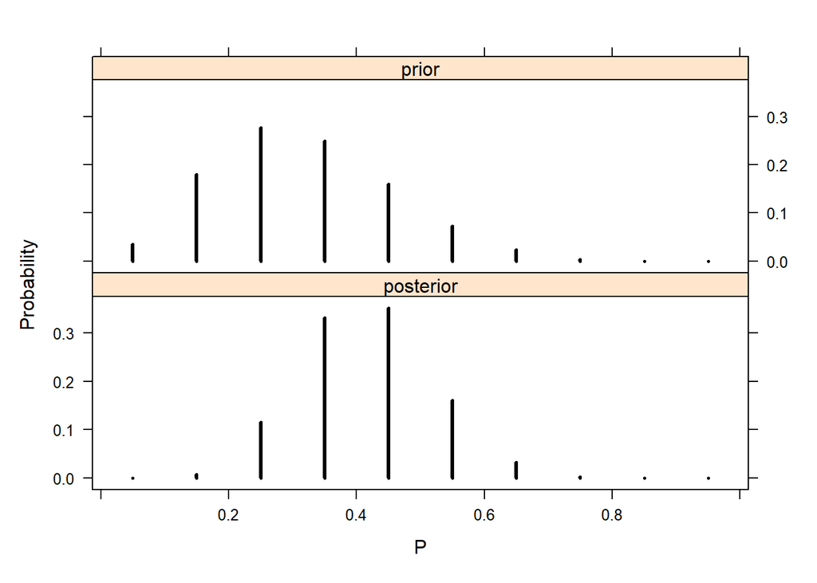

```r
library(lattice)
PRIOR <- data.frame("prior",p,prior)
POST<- data.frame("posterior",p,post)
names(PRIOR)<- c("Type","P","Probability")
names(POST)<- c("Type","P","Probability")
#
data<- rbind(PRIOR,POST)
#
xyplot(Probability~P|Type,
       data=data,
       layout=c(1,2),
       type="h",
       lwd=3,
       col="black")
```

Si noti che la distribuzione a posteriori è un compromesso tra la prior e la verosimiglianza.